# MEML_HW07

**Machine Learning for Mechanical Engineering**  
**Homework 07**  
**Due Thursday, 05/06/2021, 9:30 AM**

TA: Jongmok Lee  
Instructor: Prof. Seungchul Lee  
http://iai.postech.ac.kr/  
Industrial AI Lab at POSTECH

- For your handwritten solution, scan or take a picture of them.
- For your code, only .ipynb file will be graded.
  - Please write your NAME and student ID on your .ipynb files. ex) JongmokLee_20212781_HW07.ipynb
- Please compress all files to make a single .zip file
  - Please write your NAME and student ID on your .zip files. ex) JongmokLee_20212781_HW07.zip
  - Submit it to PLMS
- Do not submit a printed version of your code. It will not be graded.

# Problem 1

In statistics, it is important to understand the characteristics of population, sample and distributions.

1) Plot a histogram of 100,000 data points that are randomly generated from the uniform distribution.

```python
## uniform distribution
#
```

2) Plot a histogram of 100,000 data points that are randomly generated from the normal distribution.

```python
## normal distribution
#
```

3) When we select 100 data points for 1000 times from each distribution, show that the means of sampled data points approximately go to the normal distribution.

```python
## uniform distribution

Sample_N = 1000
```

```python
## normal distribution

Sample_N = 1000
```

4) Calculate covariance, covariance matrix and correlation coefficient with the below given data.

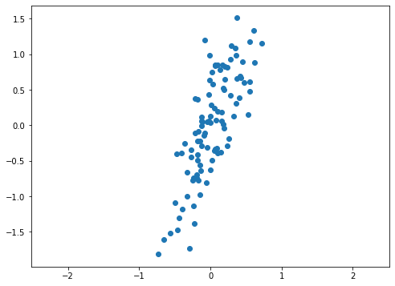

```python
x = np.random.normal(0, 0.3, 100)
data = np.array((x, 2 * x + np.random.normal(0, 0.5, 100)))

plt.figure(figsize = (8, 6))
plt.scatter(data[0], data[1])
plt.axis('equal')
plt.show()
```

```python
## write your code here
#
```

# Problem 2

Download the data [reg_pca_data](https://www.dropbox.com/s/jes6kls021e6mm3/x_reg_and_y_reg_reg_pca.zip?dl=1), and plot datas in x, y plane.

```python
from six.moves import cPickle

x_reg = cPickle.load(open('./data_files/x_reg.pkl', 'rb'))
y_reg = cPickle.load(open('./data_files/y_reg.pkl', 'rb'))
```

1) Write a python code to conduct a linear regression (least square).

```python
## your code here
#
```

2) Write a python code to perform PCA. Since `mean(x) = mean(y) = 0`, the normalization step (mean subtraction and rescaling) can be skipped.

```python
## your code here
#
```

3) Plot both the regression line and the PCA line (i.e., the first principal component) at the same time, and comment on why the results are different.

```python
## your code here
#
```

# Problem 3

```python
import numpy as np
import random
import matplotlib.pyplot as plt

%matplotlib inline
```

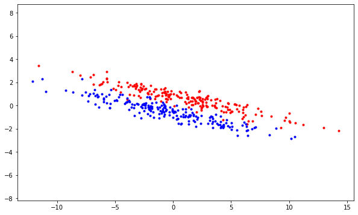

```python
n0 = 200
n1 = 200

sigma = [[19, -4],
         [-4, 1]]

x0 = np.random.multivariate_normal([0.7,0.7], sigma, n0)        # data in class 0
x1 = np.random.multivariate_normal([-0.5,-0.5], sigma, n1)      # data in class 0

x0 = np.asmatrix(x0)
x1 = np.asmatrix(x1)

plt.figure(figsize = (10, 6))
plt.plot(x0[:,0],x0[:,1],'r.')
plt.plot(x1[:,0],x1[:,1],'b.')
plt.ylim([-8, 8])
plt.xlim([-14, 14])
plt.axis('equal')
plt.show()
```

1) Plot the projection line from Fisher Discriminant Analysis.

```python
## your code here
#
```

2) Plot the projection line from PCA (i.e., the first principal component). In the case of PCA, you do not need to consider labels.(*i.e.* data class)

```python
## your code here
#
```